# Kalman filter with structural break

R. Chris Berg

10/28/2020

*(This work is all based on class notes and Matlab code offered by*[*Dr. Jeremy Piger*](https://pages.uoregon.edu/jpiger/) *for his Time Series Analysis class.)*

## Kalman filter

A Kalman filter is essentially an algorithm which gives us a best-estimate of the current value of a variable or set of variables, especially useful when there are perhaps errors in measurement. For example, it enabled NASA to estimate the location of their rockets before extremely advanced GPS systems were invented to measure location with minimal error. It works by using the previous measurement of a variable to make a prediction for the its current value based on a [state-space model](https://en.wikipedia.org/wiki/State-space_representation), then taking a current measurement to compare against the prediction, producing an “updated” estimate. Since it implies prediction errors at each step, it can be used to compute the exact likelihood of an estimate based on the state-space model, and so it is actually used for model estimation.

First you need to enforce restrictions that give you a covariance-stationary model. These function will do that for models with/out structural breaks.

```r
cons_fn_nobreak = function(uncons){
  cons = uncons

  constraint1 = uncons[4] / (1+abs(uncons[4]))
  constraint2 = uncons[5] / (1+abs(uncons[5]))

  cons[4] = constraint1 + constraint2
  cons[5] = -(constraint1*constraint2)

  cons[2] = exp(uncons[2])
  cons[3] = exp(uncons[3])

  return(cons)
}

cons_fn = function(uncons){
    cons = uncons

    constraint1 = uncons[5] / (1+abs(uncons[5]))
    constraint2 = uncons[6] / (1+abs(uncons[6]))

    cons[5] = constraint1 + constraint2
    cons[6] = -(constraint1*constraint2)

    cons[3] = exp(uncons[3])
    cons[4] = exp(uncons[4])

    return(cons)
  }
```

Next we need a function that will provide us with the likelihood estimation procedure so that we can actually select the model that will best fit the data. It actually uses a Kalman filter, but I don’t keep any of the filter estimates since that would take a lot longer and this is a function I just want R’s `optim` to run tons of times to find the best-fit model parameters.

```r
log_lik_nobreak <-
  function(theta){
    T = length(y)

    theta = cons_fn_nobreak(theta) # in case the parameters weren't going to be positive...

    delta = theta[1]
    sig_v = theta[2]
    sig_eta = theta[3]
    phi1 = theta[4]
    phi2 = theta[5]

    # setting up the state space form for the filter

    alpha = c(0 , 0)
    F = matrix( c(phi1, 1, phi2 , 0), nrow = 2)
    Q = matrix( c(sig_eta^2, 0, 0, 0), nrow = 2)
    H = matrix(c(1, -1), nrow=1)
    R = sig_v^2
    lambda = delta

    # making initial values based off class notes

    x_init = solve( diag(sqrt(length(F))) - F )%*%alpha
    v_p_init = solve(diag(length( F ))  - kronecker(F,F) )%*%matrix(Q , nrow = length(Q) , ncol = 1)
    p_init = matrix(v_p_init , nrow = sqrt(length(F)) , ncol = sqrt(length(F)) )

    x_lag = x_init
    p_lag = p_init
    LL = 0

    # the kalman filter (see class notes)
    for( t in 1:T ){
      # these are called the 'prediction equations' of the Kalman filter
      x_pred = alpha + F%*%x_lag
      p_pred = F%*%p_lag%*%t(F) + Q

      pred_err = y[t] - lambda - H%*%x_pred
      var_pred_err = H%*%p_pred%*%t(H) + R

      # these are called the 'updating equations' of the Kalman filter
      x_upd = x_pred + p_pred%*%t(H)%*%solve(var_pred_err)%*%pred_err
      p_upd = p_pred - p_pred%*%t(H)%*%solve(var_pred_err)%*%H%*%p_pred

      LL = LL -0.5*log(2*pi) -0.5*log(var_pred_err) - 0.5*(pred_err^2/var_pred_err)

      x_lag = x_upd
      p_lag = p_upd

    }
    -LL
  }

log_lik_break <-
  function(theta, B){
    T = length(y)

    theta = cons_fn(theta) # in case the parameters weren't going to be positive...

    delta1 = theta[1]
    delta2 = theta[2]
    sig_v = theta[3]
    sig_eta = theta[4]
    phi1 = theta[5]
    phi2 = theta[6]

    # setting up the state space form for the filter

    alpha = c(0 , 0)
    F = matrix( c(phi1, 1, phi2 , 0), nrow = 2)
    Q = matrix( c(sig_eta^2, 0, 0, 0), nrow = 2)
    H = matrix(c(1, -1), nrow=1)
    R = sig_v^2
    lambda1 = delta1
    lambda2 = delta2

    # making initial values based off class notes

    x_init = solve( diag(sqrt(length(F))) - F )%*%alpha
    v_p_init = solve(diag(length( F ))  - kronecker(F,F) )%*%matrix(Q , nrow = length(Q) , ncol = 1)
    p_init = matrix(v_p_init , nrow = sqrt(length(F)) , ncol = sqrt(length(F)) )

    x_lag = x_init
    p_lag = p_init
    LL = 0

    # the kalman filter (see class notes)
    for( t in 1:T ){
      if( t >= B ){
        d_t = 1
      }else{
        d_t = 0
      }
      # these are called the 'prediction equations' of the Kalman filter
      x_pred = alpha + F%*%x_lag
      p_pred = F%*%p_lag%*%t(F) + Q

      pred_err = y[t] - (1-d_t)*lambda1 - d_t*lambda2 - H%*%x_pred
      var_pred_err = H%*%p_pred%*%t(H) + R

      # these are called the 'updating equations' of the Kalman filter
      x_upd = x_pred + p_pred%*%t(H)%*%solve(var_pred_err)%*%pred_err
      p_upd = p_pred - p_pred%*%t(H)%*%solve(var_pred_err)%*%H%*%p_pred

      LL = LL -0.5*log(2*pi) -0.5*log(var_pred_err) - 0.5*(pred_err^2/var_pred_err)

      x_lag = x_upd
      p_lag = p_upd

    }
    -LL
  }
```

Now we need to alter the above functions to actually return filter and smoother estimates of variance and state values.

```r
kfest_nobreak = function(theta){
  T = length(y)

  theta = cons_fn_nobreak(theta) # in case the parameters weren't going to be positive...

  delta = theta[1]
  sig_v = theta[2]
  sig_eta = theta[3]
  phi1 = theta[4]
  phi2 = theta[5]

  # setting up the state space form for the filter

  alpha = c(0 , 0)
  F = matrix( c(phi1, 1, phi2 , 0), nrow = 2)
  Q = matrix( c(sig_eta^2, 0, 0, 0), nrow = 2)
  H = matrix(c(1, -1), nrow=1)
  R = sig_v^2
  lambda = delta

  # making initial values based off class notes

  x_init = solve( diag(sqrt(length(F))) - F )%*%alpha
  v_p_init = solve(diag(length( F ))  - kronecker(F,F) )%*%matrix(Q , nrow = length(Q) , ncol = 1)
  p_init = matrix(v_p_init , nrow = sqrt(length(F)) , ncol = sqrt(length(F)) )

  x_lag = x_init
  p_lag = p_init

  filter_out=data.frame(filter_index = 0 ,
                        cycle = 0,
                        kalman_cyc = 0,
                        var_predict = 0,
                        var_update = 0,
                        k_gain = 0)
  p_pred_list <- list()
  x_pred_list <- list()
  p_upd_list <- list()
  x_upd_list <- list()
  # the kalman filter (see class notes)
  for( t in 1:T ){

    x_pred = alpha + F%*%x_lag
    p_pred = F%*%p_lag%*%t(F) + Q

    pred_err = y[t] - lambda - H%*%x_pred
    var_pred_err = H%*%p_pred%*%t(H) + R
    kalman_gain = p_pred%*%t(H)%*%solve(var_pred_err)

    x_upd = x_pred + p_pred%*%t(H)%*%solve(var_pred_err)%*%pred_err
    p_upd = p_pred - p_pred%*%t(H)%*%solve(var_pred_err)%*%H%*%p_pred

    x_lag = x_upd
    p_lag = p_upd
    filter_out = bind_rows(filter_out,
                           data.frame(st_predict = x_pred[1],
                                      st_update = x_upd[1],
                                      var_predict = p_pred[1,1],
                                      var_update = p_upd[1,1],
                                      k_gain = kalman_gain[1,1]))

    #save model objects for the smoother step
    p_pred_list[[t]] = p_pred
    x_pred_list[[t]] = x_pred
    p_upd_list[[t]] = p_upd
    x_upd_list[[t]] = x_upd

  }
  # initialize the smoother
  x_smooth_last = x_upd_list[[T]]
  p_smooth_last = p_upd_list[[T]]
  smooth_out <- data.frame(smooth_index = T,
                           k_smooth = filter_out$kalman_cyc[T],
                           var_smooth = filter_out$var_update[T])
  #kalman smoother
  for( t in (T-1):1){
    smooth_var_pred = p_pred_list[[t+1]]
    smooth_var_upd = p_upd_list[[t]]
    smooth_est_pred = x_pred_list[[t+1]]
    smooth_est_upd = x_upd_list[[t]]

    c_k = smooth_var_upd%*%t(F)%*%solve(smooth_var_pred)
    x_smooth = smooth_est_upd+c_k%*%(x_smooth_last - smooth_est_pred)
    p_smooth = smooth_var_upd + c_k%*%(p_smooth_last - smooth_var_pred)%*%t(c_k)

    smooth_out <- bind_rows(smooth_out,
                            data.frame(smooth_index = t,
                                       k_smooth = x_smooth[1],
                                       var_smooth = p_smooth[1,1])
    )
    x_smooth_last = x_smooth
    p_smooth_last = p_smooth
  }
  data_out <- bind_cols(filter_out[-1,], arrange(smooth_out,smooth_index))
  return(data_out)
}

kfest_break = function(theta, B){
  T = length(y)

  theta = cons_fn(theta) # in case the parameters weren't going to be positive...

  delta1 = theta[1]
  delta2 = theta[2]
  sig_v = theta[3]
  sig_eta = theta[4]
  phi1 = theta[5]
  phi2 = theta[6]

  # setting up the state space form for the filter

  alpha = c(0 , 0)
  F = matrix( c(phi1, 1, phi2 , 0), nrow = 2)
  Q = matrix( c(sig_eta^2, 0, 0, 0), nrow = 2)
  H = matrix(c(1, 0), nrow=1)
  R = sig_v^2
  lambda1 = delta1
  lambda2 = delta2

  # making initial values based off class notes

  x_init = solve( diag(sqrt(length(F))) - F )%*%alpha
  v_p_init = solve(diag(length( F ))  - kronecker(F,F) )%*%matrix(Q , nrow = length(Q) , ncol = 1)
  p_init = matrix(v_p_init , nrow = sqrt(length(F)) , ncol = sqrt(length(F)) )

  x_lag = x_init
  p_lag = p_init

  filter_out=data.frame(filter_index = 0 ,
                        cycle = 0,
                        kalman_cyc = 0,
                        var_predict = 0,
                        var_update = 0,
                        k_gain = 0)
  p_pred_list <- list()
  x_pred_list <- list()
  p_upd_list <- list()
  x_upd_list <- list()
  # the kalman filter (see class notes)
  for( t in 1:T ){
    if( t >= B ){
      d_t = 1
    }else{
      d_t = 0
    }
    x_pred = alpha + F%*%x_lag
    p_pred = F%*%p_lag%*%t(F) + Q

    pred_err = y[t] - (1-d_t)*lambda1 - d_t*lambda2 - H%*%x_pred
    var_pred_err = H%*%p_pred%*%t(H) + R
    kalman_gain = p_pred%*%t(H)%*%solve(var_pred_err)

    x_upd = x_pred + p_pred%*%t(H)%*%solve(var_pred_err)%*%pred_err
    p_upd = p_pred - p_pred%*%t(H)%*%solve(var_pred_err)%*%H%*%p_pred

    x_lag = x_upd
    p_lag = p_upd
    filter_out = bind_rows(filter_out,
                           data.frame(cycle = x_pred[1],
                                      kalman_cyc = x_upd[1],
                                      var_predict = p_pred[1,1],
                                      var_update = p_upd[1,1],
                                      k_gain = kalman_gain[1,1],
                                      filter_index = t))
    #save model objects for the smoother step
    p_pred_list[[t]] = p_pred
    x_pred_list[[t]] = x_pred
    p_upd_list[[t]] = p_upd
    x_upd_list[[t]] = x_upd
  }
  # initialize the smoother
  x_smooth_last = x_upd_list[[T]]
  p_smooth_last = p_upd_list[[T]]
  smooth_out <- data.frame(smooth_index = T,
                           k_smooth = filter_out$kalman_cyc[T],
                           var_smooth = filter_out$var_update[T])
  #kalman smoother
  for( t in (T-1):1){
    smooth_var_pred = p_pred_list[[t+1]]
    smooth_var_upd = p_upd_list[[t]]
    smooth_est_pred = x_pred_list[[t+1]]
    smooth_est_upd = x_upd_list[[t]]

    c_k = smooth_var_upd%*%t(F)%*%solve(smooth_var_pred)
    x_smooth = smooth_est_upd+c_k%*%(x_smooth_last - smooth_est_pred)
    p_smooth = smooth_var_upd + c_k%*%(p_smooth_last - smooth_var_pred)%*%t(c_k)

    smooth_out <- bind_rows(smooth_out,
                            data.frame(smooth_index = t,
                                       k_smooth = x_smooth[1],
                                       var_smooth = p_smooth[1,1])
    )
    x_smooth_last = x_smooth
    p_smooth_last = p_smooth
  }
  data_out <- bind_cols(filter_out[-1,], arrange(smooth_out,smooth_index))
  return(data_out)
}
```

### Loading data

Let’s load the data to estimate the model. I use a home-spun function for pulling from the [FRED API](https://fred.stlouisfed.org/docs/api/fred/).

```r
rgdp <-
  r_fred( series = "GDPC1" ,
          freq = "q" ,
          start_date = "1952-01-01",
          last_date = "2019-07-01"
  ) %>%
  mutate(
    date = ymd(date) ,
    value = as.numeric(value) ,
    level = log(value) ,
    growth = c(NA,diff(level)*100)
  )
y = rgdp$growth[-1] # data
```

### (Log-)Likelihood parameter selection

The code chunk below is going to actually pick the right parameters– which includes the date of the structural break. This step can take a while, hence why we didn’t run the full Kalman filter for each estimate before.

```r
loglik_df = rep(0,48)
solution_df = list()

for(index in 1:48 ){
  tau = 37+4*index

  theta_in = c(mean(y[1:tau]) , mean(y[(tau+1):length(y)]) , -1 , -1 , 1, 1 )

  solution = optim(par=theta_in , fn=log_lik_break, B=tau) # maximizes likelihood function for optimal parameters
  loglik_df[index] = solution$value # value of the maximized exact log likelihood
  solution_df[[index]] = cons_fn(solution$par)
}

tau_lik <- 37+4*which(loglik_df == min(loglik_df))

theta_mle <- solution_df[[which(loglik_df == min(loglik_df))]]

theta_in_nobreak = c(mean(y) , -1 , -1 , 1, 1 )
theta_mle_nobreak = optim(par=theta_in_nobreak , fn=log_lik_nobreak)$par
```

## Kalman filter estimates

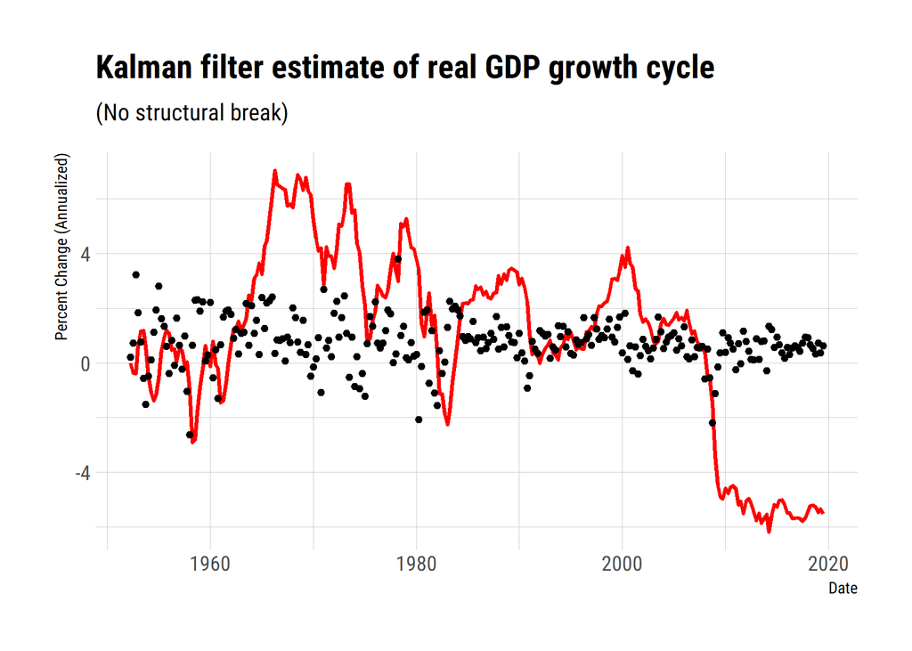

```r
library(hrbrthemes)

kf_uc_nobreak <-
  kfest_nobreak(theta_mle_nobreak) %>%
  bind_cols( growth = y ,
             date = lubridate::ymd(rgdp$date[2:length(rgdp$date)]))

ggplot(data = kf_uc_nobreak  ) +
  geom_line(aes(x = date , y = st_predict ), color = 'red' , size = 1) +
  geom_point(aes(x = date , y = growth)) +
  labs( x = "Date" ,
        y = "Percent Change (Annualized)" ,
        title = "Kalman filter estimate of real GDP growth cycle",
        subtitle = "(No structural break)")+
  theme_ipsum_rc()
```

The filter without a structural break really does not look like a very good filter. It is wildly above the data earlier in the series, and far below the data later-on. This is not what you’d expect a reasonable filter to look like! The good Dr. Piger recommends instead using a filter that allows for a structural break.

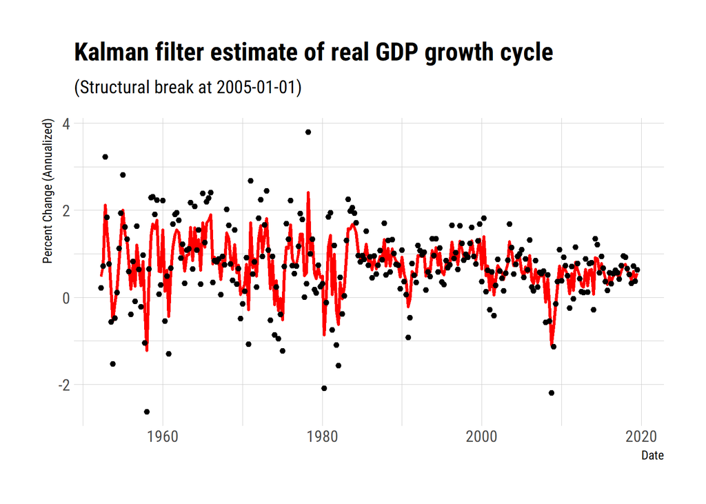

```r
kf_optim_break <-
  kfest_break(theta_mle, B=tau_lik) %>%
  bind_cols( growth = y ,
             date = lubridate::ymd(rgdp$date[2:length(rgdp$date)])) %>%
  mutate( d_t = ifelse( date < rgdp$date[tau_lik], 0, 1) ,
          trend = (1-d_t)*theta_mle[1] + d_t*theta_mle[2],
          kalman_est = kalman_cyc + trend ,
          uc_est = cycle + trend ,
          kalman_smooth = k_smooth+trend)

ggplot(data = kf_optim_break  ) +
  geom_line(aes(x = date , y = kalman_est ), color = 'red' , size = 1) +
  geom_point(aes(x = date , y = growth)) +
  labs( x = "Date" ,
        y = "Percent Change (Annualized)" ,
        title = "Kalman filter estimate of real GDP growth cycle",
        subtitle = "(Structural break at 2005-01-01)")+
  theme_ipsum_rc()
```

When we do this using the functions from above, it looks a lot better. It looks like an actual filter, which is good. Since we are given the trend-cycle decomposition…

$$\begin{align*}
Y_t &= T_t + C_t \\
T_t &= \mu + T_{t-1} + v_t \\
C_t &= \phi_1 C_{t-1} + \phi_2 C_{t-2} + \eta_t
\end{align*}$$

…where $v_t$ and $\eta_t$ are white noise, then $C_t$ is the AR(2) component without intercept. These estimated components are plotted below.

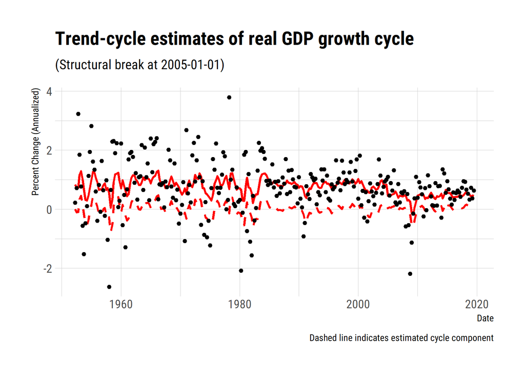

```r
ggplot(data = kf_optim_break  ) +
  geom_line(aes(x = date , y = uc_est ), color = 'red' , size = 1) +
  geom_line(aes(x = date , y = cycle ), color = 'red' , size = 1, linetype=2) +
  geom_point(aes(x = date , y = growth)) +
  labs( x = "Date" ,
        y = "Percent Change (Annualized)" ,
        title = "Trend-cycle estimates of real GDP growth cycle",
        subtitle = "(Structural break at 2005-01-01)",
        caption = "Dashed line indicates estimated cycle component")+
  theme_ipsum_rc()
```